# dummypack

Katherine Lu

## Imagine…

#### SURVEY

**What type of area do you live in?**

1. Urban
2. Suburban
3. Rural

## Q: What type of area do you live in?

Survey results: dummy variables

- AreaType1 = urban, AreaType2 = suburban, AreaType3 = rural

```r
head(data1, n = 8)
```

```
  AreaType1 AreaType2 AreaType3
1         1         0         0
2         0         1         0
3         0         1         0
4         0         1         0
5         0         1         0
6         0         1         0
7         0         0         1
8         0         1         0
```

## Objective

#### Create a function to quickly combine dummy variables into one variable with appropriate category names

## dummyvar

#### dummyvar(data, prefix, label_list, varname)

- data: your data
- prefix: prefix of group of dummy variables
- label_list: list of labels to rename dummy variables (optional)
- varname: label for your combined variable (optional)

Output: dataset with added combined variable

## Example

```r
area_labels <- c("Urban", "Suburban", "Rural")

data2 <- dummyvar(data=data1, prefix="AreaType", label_list=area_labels, varname="Area Types")
```

## Example

```r
area_labels <- c("Urban", "Suburban", "Rural")

data2 <- dummyvar(data=data1, prefix="AreaType", label_list=area_labels, varname="Area Types")
```

```r
head(data2, n=8)
```

```
  AreaType1 AreaType2 AreaType3 combined
1         1         0         0    Urban
2         0         1         0 Suburban
3         0         1         0 Suburban
4         0         1         0 Suburban
5         0         1         0 Suburban
6         0         1         0 Suburban
7         0         0         1    Rural
8         0         1         0 Suburban
```

## Example

Create a Table 1 using our new combined variable

```r
table1(~combined, data=data2)
```

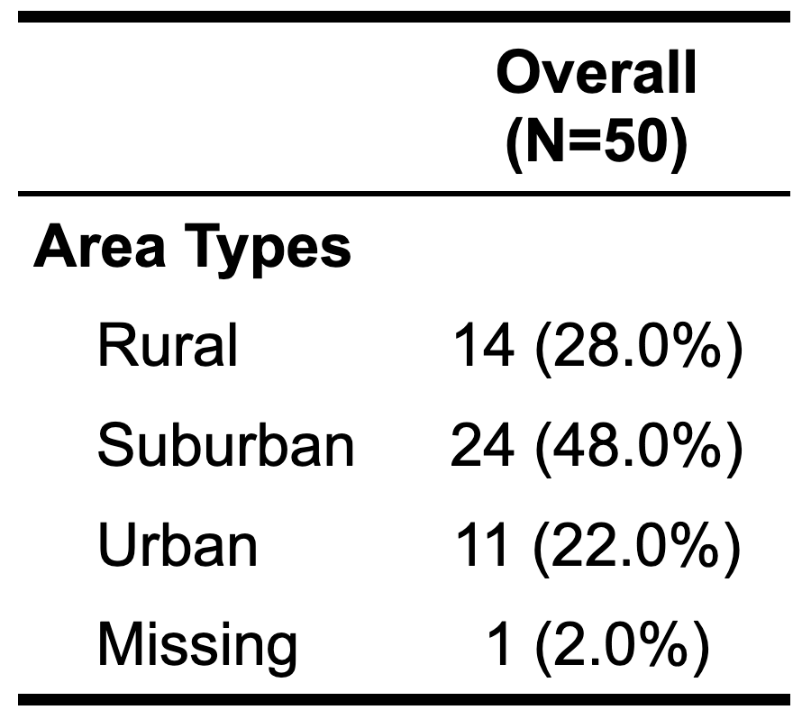

## Inside the function

```r
dummyvar <- function(data, prefix, label_list, varname){

  #subset data based on dummy vars prefix
  subset <- data %>%
    dplyr::select(dplyr::starts_with(prefix))

  #rename variables based on labels list, if provided
  if (!missing(label_list)) {
    colnames(subset) <- label_list
  }

  #create combined variable in original dataframe, using subset
  data$combined <- colnames(subset)[max.col(subset)]

  #factor the combined variable
  data$combined <- factor(data$combined)

  #label the combined variable, if varname provided
  #if not provided, use prefix
  if (missing(varname)) {
    table1::label(data$combined) <- prefix
  } else {
    table1::label(data$combined) <- varname
  }

  #return dataframe, with new combined variable
  return(data)
}
```

## What if…

#### SURVEY

**Select your top 3 most important community aspects:**

1. Health
2. Education
3. Transportation
4. Social services
5. Safety
6. Diversity and inclusion
7. Housing

## Q: Select your top 3 most important community aspects

Survey results:

- dummy variables are NOT exclusive
- cannot combine into one variable

```r
head(data1, n = 5)
```

```
  Aspect1 Aspect2 Aspect3 Aspect4 Aspect5 Aspect6 Aspect7
1       1       1       1       0       0       0       0
2       1       0       1       0       0       0       1
3       1       0       1       1       0       0       0
4       0       1       1       1       0       0       0
5       0       0       0       0       1       1       1
```

## Objective 2

#### Create a function to explore multi-option dummy variables that cannot be combined into one variable

## dummyfreq

#### dummyfreq(data, prefix, label_list, title)

- data: your data
- prefix: prefix of group of dummy variables
- label_list: list of labels to rename dummy variables (optional)
- title: title for table 1 (optional)

Output: table 1 for a set of dummy variables

## Example

```r
category_names <- c("Health", "Education", "Transportation", "Social services", "Safety", "Diversity & inclusion", "Housing")

dummyfreq(data=randomsurvey, prefix="Aspect", label_list=category_names, title="Community aspects")
```

## Example

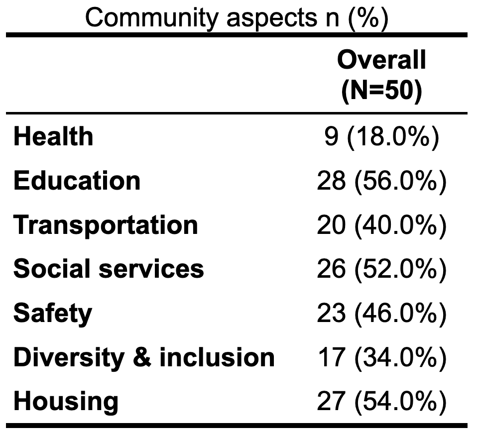

```r
category_names <- c("Health", "Education", "Transportation", "Social services", "Safety", "Diversity & inclusion", "Housing")

dummyfreq(data=randomsurvey, prefix="Aspect", label_list=category_names, title="Community aspects")
```

## Inside the function

```r
dummyfreq <- function(data, prefix, label_list, title){

  #subset data based on dummy prefix
  data <- data %>%
    dplyr::select(dplyr::starts_with(prefix))

  #rename variables based on labels list, if provided
  if (!missing(label_list)) {
    colnames(data) <- label_list
  }

  #add title if provided
  #if no title argument, use variable prefix
  if (missing(title)) {
    title1 <- paste(prefix, "n (%)")
  } else {
    title1 <- paste(title, "n (%)")
  }

  #turn dummy vars into logicals
  data[colnames(data)] <- lapply(data[colnames(data)], as.logical)

  #create render so that only TRUE is shown
  rndr <- function(x, ...) {
    y <- table1::render.default(x, ...)
    if (is.logical(x)) y[2] else y
  }

  #create table1
  return(table1::table1(~ ., data=data, caption=title1, render=rndr))
}
```

## Thank you

[figure not shown]